# Introduction to R Practical Solutions

Bristol MRC-IEU

Nov 11, 2022

## Objectives

By the end of this practical it is intended that you will be able to:

- Extract variables from a data frame
- Summarise categorical and continuous variables
- Basic plots
- Basic statistical analysis

Begin by opening RStudio and starting a new script file. Type all your code into your R script file, writing the question number and making comments with the # symbol. For example:

```r
## 1: Set the working directory
# This command sets the working directory to your documents, e.g. C:/Users/user/Documents

setwd("C:/Users/user/Documents")
```

The **setwd** function sets the working directory to a given directory, e.g. C:/Users/user/Documents

It is good practice to comment your code and split it up into sections.

## Loading and navigating a data frame

This practical is based around the Hosmer and Lemeshow data on birthweight ([lbw.csv](https://github.com/MRCIEU/introduction-to-r/blob/main/introduction/lbw.csv?raw=1)).

The **lbw** data frame contains the following information:

| Variable | Description |
| --- | --- |
| id | identification code |
| low | low birthweight (0 = birthweight>=2500g, 1 = birthweight<2500g) |
| age | age of mother (years) |
| lwt | weight of mother at last menstrual period (pounds) |
| race | race (1 = white, 2 = black, 3 = other) |
| smoke | smoked during pregnancy (0 = no, 1 = yes) |
| ptl | premature labour history (count) |
| ht | has history of hypertension (0 = no, 1 = yes) |
| ui | presence of uterine irritability (0 = no, 1 = yes) |
| ftv | number of visits to physician during 1st trimester |
| bwt | birthweight (grams) |

### Loading the lbw dataset

1. Start your R script by setting the working directory
2. Load the dataset into your R environment

```r
lbw <- read.csv("lbw.csv")
```

The **lbw** object is stored as a particular type of R object called a *data frame*.

3. The **names** function gives the list of variables stored in a *data frame*. So using the names function will show a list of column names:

```r
names(lbw)
```

```
##  [1] "id"    "low"   "age"   "lwt"   "race"  "smoke" "ptl"   "ht"    "ui"
## [10] "ftv"   "bwt"
```

The column names can be used to extract the relevant variables by using the **$** symbol. For instance, the R command:

```r
lbw$bwt
```

```
##   [1] 2523 2551 2557 2594 2600 2622 2637 2637 2663 2665 2722 2733 2750 2750 2769
##  [16] 2769 2778 2782 2807 2821 2835 2835 2836 2863 2877 2877 2906 2920 2920 2920
##  [31] 2920 2948 2948 2977 2977 2977 2977 2922 3005 3033 3042 3062 3062 3062 3076
##  [46] 3076 3080 3090 3090 3090 3100 3104 3132 3147 3175 3175 3203 3203 3203 3225
##  [61] 3225 3232 3232 3234 3260 3274 3274 3303 3317 3317 3317 3321 3331 3374 3374
##  [76] 3402 3416 3430 3444 3459 3460 3473 3475 3487 3544 3572 3572 3586 3600 3614
##  [91] 3614 3629 3629 3637 3643 3651 3651 3651 3651 3699 3728 3756 3770 3770 3770
## [106] 3790 3799 3827 3856 3860 3860 3884 3884 3912 3940 3941 3941 3969 3983 3997
## [121] 3997 4054 4054 4111 4153 4167 4174 4238 4593 4990  709 1021 1135 1330 1474
## [136] 1588 1588 1701 1729 1790 1818 1885 1893 1899 1928 1928 1928 1936 1970 2055
## [151] 2055 2082 2084 2084 2100 2125 2126 2187 2187 2211 2225 2240 2240 2282 2296
## [166] 2296 2301 2325 2353 2353 2367 2381 2381 2381 2395 2410 2410 2414 2424 2438
## [181] 2442 2450 2466 2466 2466 2495 2495 2495 2495
```

extracts the **bwt** variable.

Square brackets can also be used to obtain specific information from a data frame. We can either use a variable name or index number for the information we want.

Think of the data frame as a matrix with a specific number of columns and rows. We can use a pair of square brackets after the name of a data frame to select information. This takes the form **dataframe[row,column]**. So for example, the commands:

```r
lbw[1,]
```

```
##   id low age lwt  race smoke ptl ht ui ftv  bwt
## 1 85   0  19 182 black     0   0  0  1   0 2523
```

```r
lbw[,1]
```

```
##   [1]  85  86  87  88  89  91  92  93  94  95  96  97  98  99 100 101 102 103
##  [19] 104 105 106 107 108 109 111 112 113 114 115 116 117 118 119 120 121 123
##  [37] 124 125 126 127 128 129 130 131 132 133 134 135 136 137 138 139 140 141
##  [55] 142 143 144 145 146 147 148 149 150 151 154 155 156 159 160 161 162 163
##  [73] 164 166 167 168 169 170 172 173 174 175 176 177 179 180 181 182 183 184
##  [91] 185 186 187 188 189 190 191 192 193 195 196 197 199 200 201 202 203 204
## [109] 205 206 207 208 209 210 211 212 213 214 215 216 217 218 219 220 221 222
## [127] 223 224 225 226   4  10  11  13  15  16  17  18  19  20  22  23  24  25
## [145]  26  27  28  29  30  31  32  33  34  35  36  37  40  42  43  44  45  46
## [163]  47  49  50  51  52  54  56  57  59  60  61  62  63  65  67  68  69  71
## [181]  75  76  77  78  79  81  82  83  84
```

```r
lbw[2,1]
```

```
## [1] 86
```

select row 1 of the lbw dataframe, column 1 of the lbw dataframe, and the value in row 2 and column 1 of the data frame respectively.

### Exercise 1:

1. Write an R command that will display the **bwt** variable using square brackets.

**As bwt is the variable corresponding to column 11 in the lbw data frame, we can use either of the following commands:**

```r
lbw[,"bwt"]
```

```
##   [1] 2523 2551 2557 2594 2600 2622 2637 2637 2663 2665 2722 2733 2750 2750 2769
##  [16] 2769 2778 2782 2807 2821 2835 2835 2836 2863 2877 2877 2906 2920 2920 2920
##  [31] 2920 2948 2948 2977 2977 2977 2977 2922 3005 3033 3042 3062 3062 3062 3076
##  [46] 3076 3080 3090 3090 3090 3100 3104 3132 3147 3175 3175 3203 3203 3203 3225
##  [61] 3225 3232 3232 3234 3260 3274 3274 3303 3317 3317 3317 3321 3331 3374 3374
##  [76] 3402 3416 3430 3444 3459 3460 3473 3475 3487 3544 3572 3572 3586 3600 3614
##  [91] 3614 3629 3629 3637 3643 3651 3651 3651 3651 3699 3728 3756 3770 3770 3770
## [106] 3790 3799 3827 3856 3860 3860 3884 3884 3912 3940 3941 3941 3969 3983 3997
## [121] 3997 4054 4054 4111 4153 4167 4174 4238 4593 4990  709 1021 1135 1330 1474
## [136] 1588 1588 1701 1729 1790 1818 1885 1893 1899 1928 1928 1928 1936 1970 2055
## [151] 2055 2082 2084 2084 2100 2125 2126 2187 2187 2211 2225 2240 2240 2282 2296
## [166] 2296 2301 2325 2353 2353 2367 2381 2381 2381 2395 2410 2410 2414 2424 2438
## [181] 2442 2450 2466 2466 2466 2495 2495 2495 2495
```

```r
#or

lbw[,11]
```

```
##   [1] 2523 2551 2557 2594 2600 2622 2637 2637 2663 2665 2722 2733 2750 2750 2769
##  [16] 2769 2778 2782 2807 2821 2835 2835 2836 2863 2877 2877 2906 2920 2920 2920
##  [31] 2920 2948 2948 2977 2977 2977 2977 2922 3005 3033 3042 3062 3062 3062 3076
##  [46] 3076 3080 3090 3090 3090 3100 3104 3132 3147 3175 3175 3203 3203 3203 3225
##  [61] 3225 3232 3232 3234 3260 3274 3274 3303 3317 3317 3317 3321 3331 3374 3374
##  [76] 3402 3416 3430 3444 3459 3460 3473 3475 3487 3544 3572 3572 3586 3600 3614
##  [91] 3614 3629 3629 3637 3643 3651 3651 3651 3651 3699 3728 3756 3770 3770 3770
## [106] 3790 3799 3827 3856 3860 3860 3884 3884 3912 3940 3941 3941 3969 3983 3997
## [121] 3997 4054 4054 4111 4153 4167 4174 4238 4593 4990  709 1021 1135 1330 1474
## [136] 1588 1588 1701 1729 1790 1818 1885 1893 1899 1928 1928 1928 1936 1970 2055
## [151] 2055 2082 2084 2084 2100 2125 2126 2187 2187 2211 2225 2240 2240 2282 2296
## [166] 2296 2301 2325 2353 2353 2367 2381 2381 2381 2395 2410 2410 2414 2424 2438
## [181] 2442 2450 2466 2466 2466 2495 2495 2495 2495
```

We can also add a new variable to a data frame using the $ and <- symbols. For example, to make a variable to indicate very low birthweight, we might use the R command:

```r
lbw$vlow <- lbw$bwt < 1500
```

R uses a standard logic syntax, and good guide to logical operators available can be found [here](https://www.statmethods.net/management/operators.html).

### Exercise 2:

1. Try this command, and examine its effect on the **lbw** data frame using the **names** and **head** functions.

**Using names and head we can see that vlow has been added to the lbw data frame:**

```r
names(lbw)
```

```
##  [1] "id"    "low"   "age"   "lwt"   "race"  "smoke" "ptl"   "ht"    "ui"
## [10] "ftv"   "bwt"   "vlow"
```

```r
head(lbw)
```

```
##   id low age lwt  race smoke ptl ht ui ftv  bwt  vlow
## 1 85   0  19 182 black     0   0  0  1   0 2523 FALSE
## 2 86   0  33 155 other     0   0  0  0   3 2551 FALSE
## 3 87   0  20 105 white     1   0  0  0   1 2557 FALSE
## 4 88   0  21 108 white     1   0  0  1   2 2594 FALSE
## 5 89   0  18 107 white     1   0  0  1   0 2600 FALSE
## 6 91   0  21 124 other     0   0  0  0   0 2622 FALSE
```

## Summarising continuous variables

The following R code contains examples of functions that could be used to summarise a continuous variable, in this case the maternal age:

```r
mean(lbw$age)
```

```
## [1] 23.2381
```

```r
sd(lbw$age)
```

```
## [1] 5.298678
```

```r
median(lbw$age)
```

```
## [1] 23
```

```r
IQR(lbw$age)
```

```
## [1] 7
```

```r
mad(lbw$age)
```

```
## [1] 5.9304
```

```r
min(lbw$age)
```

```
## [1] 14
```

```r
max(lbw$age)
```

```
## [1] 45
```

```r
range(lbw$age)
```

```
## [1] 14 45
```

```r
summary(lbw$age)
```

```
##    Min. 1st Qu.  Median    Mean 3rd Qu.    Max.
##   14.00   19.00   23.00   23.24   26.00   45.00
```

### Exercise 3:

1. Write down the names of the statistics that each of these functions calculates, by looking at the help file of the function (using **help** or **?()**)

2. Use one or two of these functions to summarise the maternal age for cases with low birthweight (less than 2500g).

**The mean and standard deviation of age for mothers who have offspring with low birthweight (bwt<2500) can be computed using:**

```r
mean(lbw$age[lbw$bwt<2500])
```

```
## [1] 22.30508
```

```r
sd(lbw$age[lbw$bwt<2500])
```

```
## [1] 4.511496
```

```r
## or

mean(lbw$age[lbw$low==1])
```

```
## [1] 22.30508
```

```r
sd(lbw$age[lbw$low==1])
```

```
## [1] 4.511496
```

The R function **cor** calculates the correlation between two continuous variables. For instance, the R command:

```r
cor(lbw$lwt, lbw$bwt)
```

```
## [1] 0.1857952
```

calculates the correlation between **lwt** and **bwt**.

### Exercise 4:

1. Calculate the correlation of **age** with **lwt** and **bwt**.

**Likewise, the correlation of age with lwt and bwt can be computed using:**

```r
cor(lbw$age, lbw$lwt)
```

```
## [1] 0.1799918
```

```r
cor(lbw$age, lbw$bw)
```

```
## [1] 0.08950457
```

## Summarising categorical variables

Categorical variables are usually summarised in frequency tables. The table function is used to create frequency tables. For example:

```r
table(lbw$ptl)
```

```
##
##   0   1   2   3
## 159  24   5   1
```

creates a simple frequency table for the premature labour variable. Additional variables can be added as additional arguments to create cross-tabulations. For instance, the R command:

```r
table(lbw$ptl, lbw$smoke)
```

```
##
##       0   1
##   0 103  56
##   1  10  14
##   2   2   3
##   3   0   1
```

creates a cross-tabulation of premature labour with smoking during pregnancy.

### Exercise 5:

1. It is useful to be able to recall the table output later, so write an R command that will store the output of the above cross-tabulation in an R object called **ptl_smoke**.

**The cross-tabulation of ptl and smoke can be assigned to ptl_smoke using:**

```r
ptl_smoke <- table(lbw$ptl, lbw$smoke)
```

2. Write an R command that will produce a three-way cross-tabulation between **ptl**, **smoke** and **ht**.

**The three-way cross-tabulation of ptl, smoke and ht can be generated using:**

```r
table(lbw[,c("ptl", "smoke", "ht")])
```

```
## , , ht = 0
##
##    smoke
## ptl  0  1
##   0 98 51
##   1  8 14
##   2  2  3
##   3  0  1
##
## , , ht = 1
##
##    smoke
## ptl  0  1
##   0  5  5
##   1  2  0
##   2  0  0
##   3  0  0
```

We can add marginal totals to the table with the **addmargins** function. The R command:

```r
addmargins(ptl_smoke)
```

adds marginal totals to the table stored in the previous question. We can also re-express the table as proportions rather than frequencies. The following R commands use the **prop.table** function to achieve this:

```r
prop.table(ptl_smoke, 1)
prop.table(ptl_smoke, 2)
prop.table(ptl_smoke)
```

### Exercise 6:

1. How do these three different ways of using the **prop.table** function differ in their output?

**Each command gives row proportions, column proportions and overall proportions respectively.**

## Plotting the data

We can use the **plot** function generate a scatter plot showing bwt versus lwt:

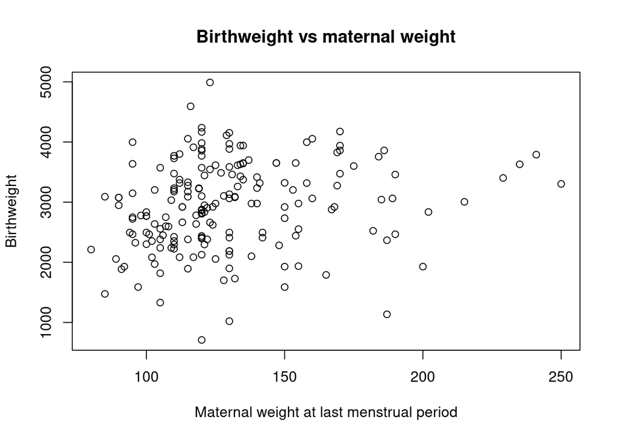

```r
plot(lbw$lwt, lbw$bwt, xlab = "Maternal weight at last menstrual period",
    ylab = "Birthweight", main = "Birthweight vs maternal weight")
```

### Exercise 7:

1. Use the **hist** and **boxplot** to investigate the distribution of age.

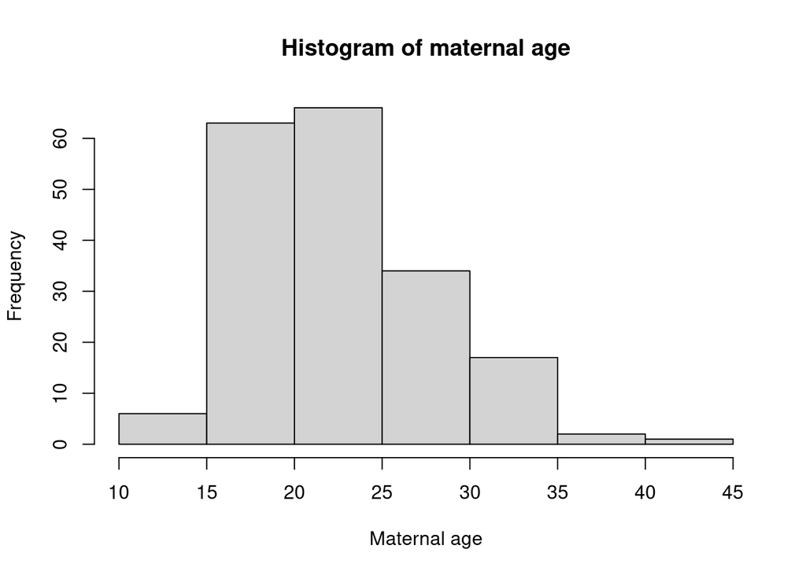

```r
# The histogram of age can be plotted using:
hist(lbw$age, xlab="Maternal age", main="Histogram of maternal age")
```

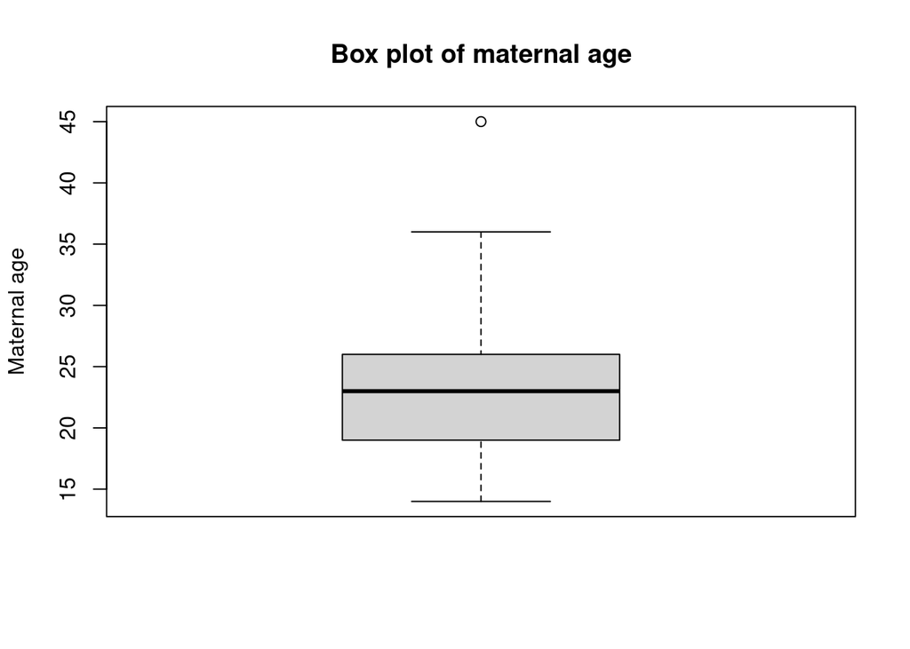

```r
# The box plot of age can be plotted using:
boxplot(lbw$age, ylab="Maternal age", main="Box plot of maternal age")
```

## Linear regression

The following R command performs a basic linear regression of **bwt** against **lwt**:

```r
lm(bwt ~ lwt, data=lbw)
```

```
##
## Call:
## lm(formula = bwt ~ lwt, data = lbw)
##
## Coefficients:
## (Intercept)          lwt
##     2369.18         4.43
```

The first argument **bwt ~ lwt**, the formula, describes the dependent and independent variables in the linear regression. The second argument **data=lbw** specifies that **bwt** and **lwt** can be found in the **lbw** data frame. The output of lm only provides the beta coefficients. We can store all this information by storing the output as an R object, for instance with the command:

```r
model <- lm(bwt ~ lwt, data=lbw)
```

### Exercise 8:

1. What happens when you apply the summary function to the R object **model**?

**The summary function gives you more information on the regression model (e.g. standard errors of the regression coefficients):**

```r
summary(model)
```

```
##
## Call:
## lm(formula = bwt ~ lwt, data = lbw)
##
## Residuals:
##      Min       1Q   Median       3Q      Max
## -2191.78  -503.24    -3.52   508.66  2075.93
##
## Coefficients:
##             Estimate Std. Error t value Pr(>|t|)
## (Intercept) 2369.184    228.467  10.370   <2e-16 ***
## lwt            4.430      1.713   2.586   0.0105 *
## ---
## Signif. codes:  0 '***' 0.001 '**' 0.01 '*' 0.05 '.' 0.1 ' ' 1
##
## Residual standard error: 718.2 on 187 degrees of freedom
## Multiple R-squared:  0.03452,    Adjusted R-squared:  0.02936
## F-statistic: 6.686 on 1 and 187 DF,  p-value: 0.01048
```

2. Use the **names** function to see what named objects are available in **model** (an explanation is available in the **lm** help file).

**The names function can be used to show the components within model:**

```r
names(model)
```

```
##  [1] "coefficients"  "residuals"     "effects"       "rank"
##  [5] "fitted.values" "assign"        "qr"            "df.residual"
##  [9] "xlevels"       "call"          "terms"         "model"
```